# Preliminary Analysis: Income and Depression Patterns

## Question

How is family income-to-poverty ratio associated with PHQ-9 depression symptom scores among adults aged 18 and older in NHANES 2021–2023?

## Setup 1 - Merging the two NHANES datasets, making the PHQ-9 score variable, and making the categorical age variable

```r
#AI prompt: Read the NHANES 2021-2023 DEMO_L.xpt and DPQ_L.xpt datasets, merge them into a csv dataset, and create a new variable dpq_score that is the sum of DPQ010 through DPQ090. Also create a categorical age variable age_cat with bands <18, 18-29, 30-39, 40-49, 50-59, 60-69, 70-79, and 80+.
#Verified: The merged dataset has 6,337 rows, and the dpq_score variable matches independent calculations of the PHQ-9 total score. The age_cat variable has the expected distribution of adults across the bands. All of this was compared with the NHANES data codebook.

library(haven)
library(dplyr)

project_root <- normalizePath(
  system2("git", c("rev-parse", "--show-toplevel"), stdout = TRUE),
  mustWork = TRUE
)
raw_dir <- file.path(project_root, "data", "raw")
data_dir <- file.path(project_root, "data")

demographics <- read_xpt(file.path(raw_dir, "DEMO_L.xpt"))
depression <- read_xpt(file.path(raw_dir, "DPQ_L.xpt"))

stopifnot(!anyDuplicated(demographics$SEQN), !anyDuplicated(depression$SEQN))

nhanes_merged <- inner_join(demographics, depression, by = "SEQN")
stopifnot(nrow(nhanes_merged) == n_distinct(nhanes_merged$SEQN))

dpq_items <- paste0("DPQ0", seq(10, 90, by = 10))
nhanes_merged <- nhanes_merged |>
  mutate(across(
    all_of(dpq_items),
    ~ if_else(.x %in% c(7, 9), NA_real_, .x)
  )) |>
  mutate(
    dpq_missing = rowSums(is.na(across(all_of(dpq_items)))),
    dpq_score = case_when(
      is.na(DPQ090) | dpq_missing >= 3L ~ NA_real_,
      dpq_missing == 0L ~ rowSums(across(all_of(dpq_items))),
      dpq_missing %in% c(1L, 2L) ~
        rowMeans(across(all_of(dpq_items)), na.rm = TRUE) * 9,
      .default = NA_real_
    )
  ) |>
  select(-dpq_missing) |>
  mutate(age_cat = cut(
    RIDAGEYR,
    breaks = c(-Inf, 18, 30, 40, 50, 60, 70, 80, Inf),
    right = FALSE,
    include.lowest = TRUE,
    ordered_result = TRUE,
    labels = c("<18", "18-29", "30-39", "40-49", "50-59", "60-69", "70-79", "80+")
  ))

write.csv(
  nhanes_merged,
  file.path(data_dir, "nhanes_merged.csv"),
  row.names = FALSE,
  na = ""
)

nrow(nhanes_merged)
```

```
[1] 6337
```

## Setup 2 - Importing the new dataset

```r
library(tidyverse)
library(knitr)
library(gt)

nhanes <- read_csv(
  file.path(project_root, "data", "nhanes_merged.csv"),
  show_col_types = FALSE
)

submission_dir <- file.path(
  project_root,
  "milestones",
  "m2-preliminary-analysis",
  "submission"
)
```

## Cohort

We limited the analysis to adults aged 18 years and older. All 6,337 records in the merged dataset met this age criterion, so no records were removed at this step. Missing income and PHQ-9 scores were assessed before selecting complete cases for the analysis.

```r
adult_cohort <- nhanes |>
  filter(RIDAGEYR >= 18)

cohort_counts <- tibble(
  step = c("Prepared file", "After age 18+ restriction"),
  n = c(nrow(nhanes), nrow(adult_cohort))
)

kable(cohort_counts)
```

| step | n |
| --- | --- |
| Prepared file | 6337 |
| After age 18+ restriction | 6337 |

## Missingness

Missingness for family income-to-poverty ratio, PHQ-9 score and age was assessed among all adults aged 18 years and older before restricting the data to complete cases.

```r
# AI prompt, original code (Humnah): Help draft code to summarize missingness for INDFMPIR and dpq_score before complete-case filtering and export the result as a CSV.
# Verified: Missing counts were independently checked using is.na() on the adult cohort.

# AI prompt, update (Morgan): Add RIDAGEYR (numeric age in years) to key_vars with the label "Age", so every
#   Table 1 variable has a missingness row, and round missing_percent to one decimal.
# Verified: the Age row shows 0 missing (the age 18+ filter already drops any missing age);
#   sum(is.na(adult_cohort$RIDAGEYR)) is 0; the CSV percents have one decimal.

key_vars <- c("INDFMPIR", "dpq_score", "RIDAGEYR")

missingness_summary <- adult_cohort |>
  summarise(
    across(
      all_of(key_vars),
      ~ sum(is.na(.x))
    )
  ) |>
  pivot_longer(
    cols = everything(),
    names_to = "variable",
    values_to = "missing_n"
  ) |>
  mutate(
    total_n = nrow(adult_cohort),
    missing_percent = round(100 * missing_n / total_n, 1),
    variable = recode(
      variable,
      INDFMPIR = "Family income-to-poverty ratio",
      dpq_score = "PHQ-9 total score",
      RIDAGEYR = "Age"
    )
  )

missingness_summary |>
  gt() |>
  tab_header(
    title = "Missingness in Key Analysis Variables",
    subtitle = "Adults aged 18 years and older, NHANES 2021–2023"
  ) |>
  cols_label(
    variable = "Variable",
    missing_n = "Missing, n",
    total_n = "Cohort N",
    missing_percent = "Missing (%)"
  ) |>
  fmt_number(
    columns = missing_percent,
    decimals = 1
  ) |>
  opt_row_striping()
```

Missingness in Key Analysis Variables

Adults aged 18 years and older, NHANES 2021–2023

| Variable | Missing, n | Cohort N | Missing (%) |
| --- | --- | --- | --- |
| Family income-to-poverty ratio | 831 | 6337 | 13.1 |
| PHQ-9 total score | 838 | 6337 | 13.2 |
| Age | 0 | 6337 | 0.0 |

```r
write_csv(
  missingness_summary,
  file.path(submission_dir, "missingness-summary.csv")
)
```

PHQ-9 answers coded 7 (refused) or 9 (don’t know) were set to missing before scoring. The table below counts them across the nine items, using the screener file before recoding.

```r
# Refused and don't know answers, counted before they were set to missing
# AI prompt: R/dplyr. Tibble depression (raw NHANES DPQ_L, one row per adult) has numeric
#   columns DPQ010 to DPQ090 coded 0-3, 7 (refused), 9 (don't know) or NA. Count across all
#   nine items: the total 7s, the total 9s, and the number of adults with at least one 7 or 9.
# Verified: DPQ010 alone gives 5 refused and 16 don't know, matching the CDC DPQ_L codebook;
#   the totals match sum(depression[dpq_items] == 7, na.rm = TRUE) and the same with 9.
item_codes <- depression[dpq_items]

refused_dont_know <- tibble(
  measure = c("Answers coded 7 (refused)",
              "Answers coded 9 (don't know)",
              "Adults with at least one 7 or 9"),
  n = c(
    sum(item_codes == 7, na.rm = TRUE),
    sum(item_codes == 9, na.rm = TRUE),
    sum(rowSums(item_codes == 7 | item_codes == 9, na.rm = TRUE) > 0)
  )
)

kable(refused_dont_know)
```

| measure | n |
| --- | --- |
| Answers coded 7 (refused) | 23 |
| Answers coded 9 (don’t know) | 51 |
| Adults with at least one 7 or 9 | 53 |

## Analytic sample

After documenting missingness, we restricted the analysis to adults with non-missing family income-to-poverty ratio and PHQ-9 scores.

```r
analysis_df <- adult_cohort |>
  filter(
    !is.na(INDFMPIR),
    !is.na(dpq_score)
  )

# Add the complete-case step to the cohort flow table from the Cohort section
# AI prompt: R/tibble. Tibble cohort_counts has columns step (character) and n (integer). Add a
#   row for the complete-case step with n = nrow(analysis_df), then print it with kable().
# Verified: the new last row's n equals nrow(analysis_df); the first two rows are unchanged.
cohort_counts <- cohort_counts |>
  add_row(step = "After excluding missing income ratio or PHQ-9 total", n = nrow(analysis_df))

kable(cohort_counts)
```

| step | n |
| --- | --- |
| Prepared file | 6337 |
| After age 18+ restriction | 6337 |
| After excluding missing income ratio or PHQ-9 total | 4831 |

## Table 1 style summary

Table 1 describes the analytic sample: adults aged 18 and older with both a family income-to-poverty ratio and a PHQ-9 total. It shows the sample overall and within one-unit bands of the ratio, which keep its order visible. The top band holds everyone at the NHANES top code of 5. PHQ-9 scores are skewed, with an SD larger than the mean, but we report mean (SD) to match the figure.

```r
# Income-to-poverty bands (moved here from the figure chunk so Table 1 and the figure share them)
# AI prompt: R/dplyr. Data frame analysis_df has numeric INDFMPIR (family income-to-poverty
#   ratio, 0 to 5, two decimals; 5 is a top code meaning "5 or higher") and numeric dpq_score
#   (PHQ-9 total, 0-27, no NAs). Write cut() bands [0,1), [1,2), [2,3), [3,4), [4,5), [5,Inf)
#   labelled "Under 1" to "5 or higher" so every row gets a band.
# Verified: cut(c(0, 0.99, 1, 4.99, 5), breaks = band_breaks, labels = band_labels, right = FALSE)
#   puts each test value in the expected band; anyNA(analysis_df$income_band) is FALSE.
band_breaks <- c(0, 1, 2, 3, 4, 5, Inf)
band_labels <- c("Under 1", "1 to under 2", "2 to under 3",
                 "3 to under 4", "4 to under 5", "5 or higher")

analysis_df <- analysis_df |>
  mutate(income_band = cut(INDFMPIR, breaks = band_breaks,
                           labels = band_labels, right = FALSE))

# Table 1: one row for all adults, then one row per income band
# Source: M2 worked example, "Table 1-style summary" chunk (group_by + summarise, sprintf for
#   mean (SD), kable, write_csv). Our columns replace IncomeGroup, BMI and Age.
# AI prompt: R/dplyr. Tibble analysis_df has factor income_band (6 levels), numeric dpq_score
#   (PHQ-9 total, 0-27, no NAs) and numeric RIDAGEYR (age, no NAs). Keep the group_by +
#   summarise pattern, but add an "All adults" row above the band rows and a
#   percent-of-sample column.
# Verified: the "All adults" N equals nrow(analysis_df); the six band Ns add up to the same
#   total and match the n labels on the figure; the "All adults" PHQ-9 mean (SD) matches
#   mean() and sd() run on analysis_df$dpq_score.
table1 <- analysis_df |>
  # Stack a copy of every row labelled "All adults", so one summarise() gives both
  #   the overall row and the band rows
  mutate(income_band = "All adults") |>
  bind_rows(analysis_df) |>
  mutate(income_band = factor(income_band, levels = c("All adults", band_labels))) |>
  group_by(income_band) |>
  summarise(
    N = n(),
    `% of sample` = sprintf("%.1f", 100 * n() / nrow(analysis_df)),
    `PHQ-9, mean (SD)` = sprintf("%.1f (%.1f)", mean(dpq_score), sd(dpq_score)),
    `Age, mean (SD)` = sprintf("%.1f (%.1f)", mean(RIDAGEYR), sd(RIDAGEYR)),
    .groups = "drop"
  ) |>
  rename(`Family income-to-poverty ratio` = income_band)

kable(
  table1,
  caption = "Table 1. Characteristics of the analytic sample, overall and by family income-to-poverty ratio. A ratio under 1 means family income below the federal poverty guideline."
)
```

Table 1. Characteristics of the analytic sample, overall and by family income-to-poverty ratio. A ratio under 1 means family income below the federal poverty guideline.

| Family income-to-poverty ratio | N | % of sample | PHQ-9, mean (SD) | Age, mean (SD) |
| --- | --- | --- | --- | --- |
| All adults | 4831 | 100.0 | 4.2 (4.8) | 52.3 (18.1) |
| Under 1 | 731 | 15.1 | 5.7 (5.7) | 47.3 (18.1) |
| 1 to under 2 | 932 | 19.3 | 5.2 (5.5) | 52.2 (18.8) |
| 2 to under 3 | 792 | 16.4 | 4.4 (4.9) | 52.7 (19.3) |
| 3 to under 4 | 618 | 12.8 | 3.8 (4.2) | 53.8 (18.2) |
| 4 to under 5 | 479 | 9.9 | 3.5 (4.2) | 55.3 (17.3) |
| 5 or higher | 1279 | 26.5 | 3.0 (3.6) | 53.1 (16.3) |

```r
write_csv(
  table1,
  file.path(submission_dir, "table1.csv")
)
```

## Preliminary figure

The figure shows the mean PHQ-9 total score in each income band from Table 1.

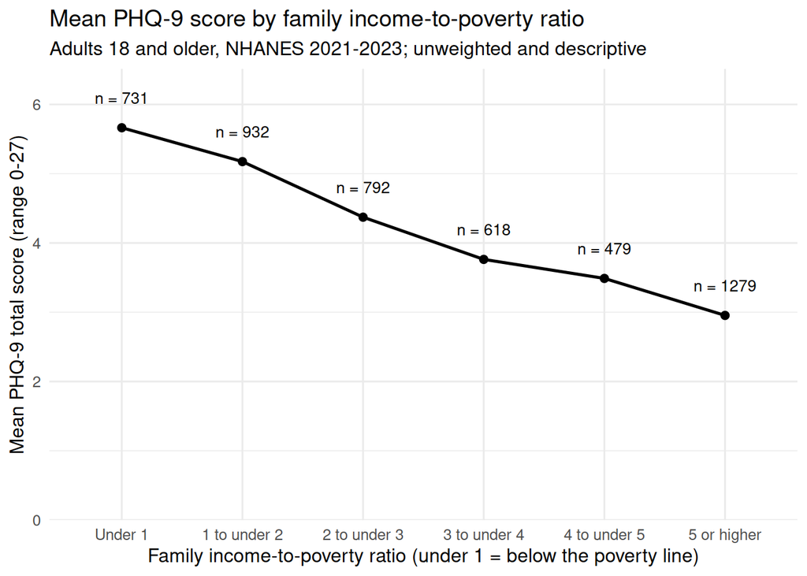

Mean PHQ-9 total score by band of family income-to-poverty ratio among adults aged 18 and older, NHANES 2021-2023. Adults missing an income ratio or a PHQ-9 total were excluded. Values are unweighted and descriptive, not causal or population estimates. NHANES top-codes the ratio at 5, so the last band includes everyone at 5 or higher.

```r
# Grouped summary
# Source: M2 worked example, "Preliminary figure" chunk (group_by + summarise, keep n >= 30).
#   Our columns replace Cycle, IncomeGroup and BMI. Uses the income_band column made in Table 1.
income_band_summary <- analysis_df |>
  group_by(income_band) |>
  summarise(n = n(), mean_phq9 = mean(dpq_score), .groups = "drop") |>
  filter(n >= 30)

# Figure
# Source: M2 worked example ggplot (geom_line + geom_point, expand_limits(y = 0), labs,
#   theme_minimal). One series here, so no colour scale.
# AI prompt: Add a label "n = <count>" above each point from column n, far enough above that
#   it clears the line, and add headroom at the top of the y axis so the highest label fits.
# Verified: the n labels match income_band_summary$n; the "5 or higher" point matches
#   mean(analysis_df$dpq_score[analysis_df$INDFMPIR >= 5]).
ggplot(income_band_summary, aes(x = income_band, y = mean_phq9, group = 1)) +
  geom_line(linewidth = 0.9) +
  geom_point(size = 2) +
  geom_text(aes(label = paste0("n = ", n)), vjust = -2, size = 3.5) +
  expand_limits(y = 0) +
  scale_y_continuous(expand = expansion(mult = c(0, 0.15))) +
  labs(
    title = "Mean PHQ-9 score by family income-to-poverty ratio",
    subtitle = "Adults 18 and older, NHANES 2021-2023; unweighted and descriptive",
    x = "Family income-to-poverty ratio (under 1 = below the poverty line)",
    y = "Mean PHQ-9 total score (range 0-27)"
  ) +
  theme_minimal(base_size = 12)
```

## Interpretation

Mean PHQ-9 score fell with each step up in family income-to-poverty ratio, from 5.7 among adults below the poverty line to 3.0 among adults at a ratio of 5 or higher. The pattern is steady enough to justify a fuller analysis, but the 2.7-point gap is small next to the spread of scores across the sample (standard deviation 4.8, Table 1), so individual scores overlap a lot between bands.

## What this analysis cannot claim

These results are descriptive and do not use the NHANES survey weights, so they describe the adults in this sample, not all U.S. adults. The data are cross-sectional, and the comparisons are not adjusted for other factors such as age or health. As a result, they cannot show that lower income causes depressive symptoms, or rule out that symptoms affect income. The PHQ-9 is a screening tool, not a diagnosis, so mean scores do not show how many adults have depression. Adults missing an income ratio or a PHQ-9 total are not included, and the pattern could differ if they differ from the adults we kept.